# Simple graphs/tables

Mathilde Le Vu

2022-07-10

# Opening the data file

```r
bevn <- read.csv2(here("data", "birth_iem.csv"))
```

## Geburtsstaat = State and world region of birth

```r
#8999 doesnt correspond to anything in the codebook but probably NA
  table(bevn$Geburtsstaat, useNA = "always")
```

```
##
##    8100    8201    8202    8204    8205    8206    8207    8211    8212    8214
## 2824645      36       4    1853      73     571   19909     375   32741     648
##    8215    8216    8217    8218    8220    8222    8223    8224    8226    8227
##    7957     345      62    8549      15     645     300      39     177    1542
##    8228    8229    8230    8231    8232    8233    8234    8236    8238    8239
##     543    3830     240     460     133       1    1124    3870       7    1193
##    8240    8242    8243    8244    8248    8250    8251    8252    8254    8255
##     255      58      70     311     501     262      71     116      29     165
##    8256    8260    8261    8262    8263    8264    8265    8266    8301    8302
##     263      22      18       8      11     348     110      18       2      66
##    8303    8304    8305    8307    8308    8309    8310    8311    8312    8313
##       1     234      17      12      11      11      86       7      27      75
##    8314    8315    8317    8319    8320    8322    8323    8324    8325    8326
##       4      48     109      13     207       8      50       2       2      30
```

[output cut: 26 more lines]

```r
#assign NA to values=8999
  bevn$Geburtsstaat[bevn$Geburtsstaat ==8999] = NA

# categorizing state of birth in : Switzerland or Outside of Switzerland
  bevn$Geburtsstaat_cat1 <- cut(bevn$Geburtsstaat, breaks=c(8000, 8100, 10000), include.lowest=TRUE, labels=c("Switzerland", "Outside Switzerland"))
  table(bevn$Geburtsstaat_cat1, useNA = "always")
```

```
##
##         Switzerland Outside Switzerland                <NA>
##             2824645              148335                   5
```

```r
  round(prop.table(table(bevn$Geburtsstaat_cat1, useNA="always"))*100,2)
```

```
##
##         Switzerland Outside Switzerland                <NA>
##               95.01                4.99                0.00
```

```r
#categorizing state of birth in : Switzerland, Europe, Africa, Americas, Asia, Oceania, other
  bevn$Geburtsstaat_cat2 <- cut(bevn$Geburtsstaat, breaks=c(8000, 8100, 8280, 8384, 8486, 8601, 8685, 10000), include.lowest=TRUE, labels=c("Switzerland", "Europe - excl Switz", "Africa", "Americas", "Asia", "Oceania", "Other"))
table(bevn$Geburtsstaat_cat2, useNA = "always")
```

```
##
##         Switzerland Europe - excl Switz              Africa            Americas
##             2824645               89878                4803               30639
##                Asia             Oceania               Other                <NA>
##               21840                1175                   0                   5
```

```r
round(prop.table(table(bevn$Geburtsstaat_cat2, useNA="always"))*100,2)
```

```
##
##         Switzerland Europe - excl Switz              Africa            Americas
##               95.01                3.02                0.16                1.03
##                Asia             Oceania               Other                <NA>
##                0.73                0.04                0.00                0.00
```

```r
#categorizing state of birth in : Switzerland, different parts of Europe, other
bevn$Geburtsstaat_cat3 <- as.factor(ifelse(bevn$Geburtsstaat == 8100, 'Switz',
                                    ifelse(bevn$Geburtsstaat == 8207 | bevn$Geburtsstaat == 8208 | bevn$Geburtsstaat == 8209 | bevn$Geburtsstaat == 8222 | bevn$Geburtsstaat == 8229 | bevn$Geburtsstaat == 8230 | bevn$Geburtsstaat == 8238 | bevn$Geburtsstaat == 8243 | bevn$Geburtsstaat == 8244,  'Central Europe',
                                    ifelse (bevn$Geburtsstaat == 8201 | bevn$Geburtsstaat == 8205 | bevn$Geburtsstaat ==8220 | bevn$Geburtsstaat == 8232 | bevn$Geburtsstaat == 82880 | (bevn$Geburtsstaat > 8247 & bevn$Geburtsstaat< 8258) , 'SE Europe',
                                    ifelse(bevn$Geburtsstaat==8202 | bevn$Geburtsstaat== 8213 | bevn$Geburtsstaat==8231 |bevn$Geburtsstaat== 8236, 'SW Europe',
                                    ifelse(bevn$Geburtsstaat==8204 | bevn$Geburtsstaat==8212 |bevn$Geburtsstaat==8215|bevn$Geburtsstaat==8216|bevn$Geburtsstaat==8223|bevn$Geburtsstaat==8225|bevn$Geburtsstaat==8226|bevn$Geburtsstaat==8227|bevn$Geburtsstaat==8270|bevn$Geburtsstaat==8271|bevn$Geburtsstaat==8272|bevn$Geburtsstaat==8275, 'Western Europe',
                                 ifelse(bevn$Geburtsstaat==8206|bevn$Geburtsstaat==8210|bevn$Geburtsstaat==8211|bevn$Geburtsstaat==8217|bevn$Geburtsstaat==8228|bevn$Geburtsstaat==8234|bevn$Geburtsstaat==8273|bevn$Geburtsstaat==8274,'Northern Europe',
                                ifelse(bevn$Geburtsstaat==8214|bevn$Geburtsstaat==8218|bevn$Geburtsstaat==8224|bevn$Geburtsstaat==8233|bevn$Geburtsstaat==8239|bevn$Geburtsstaat==8241|bevn$Geburtsstaat==8242, 'Southern Europe',
                                ifelse(bevn$Geburtsstaat==8235|bevn$Geburtsstaat==8572|bevn$Geburtsstaat==8573|bevn$Geburtsstaat==8574|bevn$Geburtsstaat==8576|bevn$Geburtsstaat==8577|bevn$Geburtsstaat==8578 | (bevn$Geburtsstaat > 8259 & bevn$Geburtsstaat < 8267), 'Eastern Europe','other')))))))))

round(prop.table(table(bevn$Geburtsstaat_cat3, useNA="always"))*100,2)
```

```
##
##  Central Europe  Eastern Europe Northern Europe           other       SE Europe
##            0.84            0.02            0.09            1.97            0.06
## Southern Europe       SW Europe           Switz  Western Europe            <NA>
##            0.35            0.15           95.01            1.51            0.00
```

There are **148,335** births that occurred outside of Switzerland.

## Mutter: Staatsangehörigkeit = Nationality Mother

See separate codebook

```r
summary(bevn$Mutter..Staatsangehörigkeit)
```

```
##    Min. 1st Qu.  Median    Mean 3rd Qu.    Max.
##    8100    8100    8100    8163    8218    8999
```

```r
table(bevn$Mutter..Staatsangehörigkeit, useNA="always")
```

```
##
##    8100    8201    8202    8204    8205    8206    8207    8211    8212    8214
## 1936844    1713      13    5633    2629    2583  105366    2325   61646    3412
##    8215    8216    8217    8218    8220    8222    8223    8224    8226    8227
##   15121    1705     188  102828   27674    3179     432      76      10    8153
##    8228    8229    8230    8231    8232    8233    8234    8235    8236    8238
##    1311   13948   10231  102375    6417      12    4352      78   35884     278
##    8239    8240    8241    8242    8243    8244    8248    8250    8251    8252
##   50432    5628       4     114    5659    4004   90207   15638    1457   17873
##    8254    8255    8256    8260    8261    8262    8263    8264    8265    8266
##     646   35686   32024     410    1070     860     742    9384    4672     860
##    8301    8302    8303    8304    8305    8307    8308    8309    8310    8311
##      27    2603      33    3619    2942      16     258     183    1314      99
##    8312    8313    8314    8315    8317    8319    8320    8321    8322    8323
##     159    1111      98     521    3052     848    1164      13     666    4094
```

[output cut: 26 more lines]

```r
# categorizing nationality of the mother in : Switzerland or Outside of Switzerland
  bevn$mother_nationality_cat1 <- cut(bevn$Mutter..Staatsangehörigkeit, breaks=c(8000, 8100, 10000), include.lowest=TRUE, labels=c("Switzerland", "Outside Switzerland"))
  round(prop.table(table(bevn$mother_nationality_cat1, useNA="always"))*100,2)
```

```
##
##         Switzerland Outside Switzerland                <NA>
##               65.15               34.85                0.00
```

```r
# categorizing nationality of the mother in : Switzerland, Europe, Africa, Americas, Asia, Oceania, other
  bevn$mother_nationality_cat2 <- cut(bevn$Mutter..Staatsangehörigkeit, breaks=c(8000, 8100, 8280, 8384, 8486, 8601, 8685, 10000), include.lowest=TRUE, labels=c("Switzerland", "Europe - excl Switz", "Africa", "Americas", "Asia", "Oceania", "Other"))
round(prop.table(table(bevn$mother_nationality_cat2, useNA="always"))*100,2)
```

```
##
##         Switzerland Europe - excl Switz              Africa            Americas
##               65.15               26.81                2.16                2.36
##                Asia             Oceania               Other                <NA>
##                3.28                0.03                0.22                0.00
```

```r
#categorizing nationality of the mother in : Switzerland, different parts of Europe, other
bevn$mother_nationality_cat3 <- as.factor(ifelse(bevn$Mutter..Staatsangehörigkeit == 8100, 'Switz',
                                    ifelse(bevn$Mutter..Staatsangehörigkeit == 8207 | bevn$Mutter..Staatsangehörigkeit == 8208 | bevn$Mutter..Staatsangehörigkeit == 8209 | bevn$Mutter..Staatsangehörigkeit == 8222 | bevn$Mutter..Staatsangehörigkeit == 8229 | bevn$Mutter..Staatsangehörigkeit == 8230 | bevn$Mutter..Staatsangehörigkeit == 8238 | bevn$Mutter..Staatsangehörigkeit == 8243 | bevn$Mutter..Staatsangehörigkeit == 8244,  'Central Europe',
                                    ifelse (bevn$Mutter..Staatsangehörigkeit == 8201 | bevn$Mutter..Staatsangehörigkeit == 8205 | bevn$Mutter..Staatsangehörigkeit ==8220 | bevn$Mutter..Staatsangehörigkeit == 8232 | bevn$Mutter..Staatsangehörigkeit == 82880 | (bevn$Mutter..Staatsangehörigkeit > 8247 & bevn$Mutter..Staatsangehörigkeit< 8258) , 'SE Europe',
                                    ifelse(bevn$Mutter..Staatsangehörigkeit==8202 | bevn$Mutter..Staatsangehörigkeit== 8213 | bevn$Mutter..Staatsangehörigkeit==8231 |bevn$Mutter..Staatsangehörigkeit== 8236, 'SW Europe',
                                    ifelse(bevn$Mutter..Staatsangehörigkeit==8204 | bevn$Mutter..Staatsangehörigkeit==8212 |bevn$Mutter..Staatsangehörigkeit==8215|bevn$Mutter..Staatsangehörigkeit==8216|bevn$Mutter..Staatsangehörigkeit==8223|bevn$Mutter..Staatsangehörigkeit==8225|bevn$Mutter..Staatsangehörigkeit==8226|bevn$Mutter..Staatsangehörigkeit==8227|bevn$Mutter..Staatsangehörigkeit==8270|bevn$Mutter..Staatsangehörigkeit==8271|bevn$Mutter..Staatsangehörigkeit==8272|bevn$Mutter..Staatsangehörigkeit==8275, 'Western Europe',
                                 ifelse(bevn$Mutter..Staatsangehörigkeit==8206|bevn$Mutter..Staatsangehörigkeit==8210|bevn$Mutter..Staatsangehörigkeit==8211|bevn$Mutter..Staatsangehörigkeit==8217|bevn$Mutter..Staatsangehörigkeit==8228|bevn$Mutter..Staatsangehörigkeit==8234|bevn$Mutter..Staatsangehörigkeit==8273|bevn$Mutter..Staatsangehörigkeit==8274,'Northern Europe',
                                ifelse(bevn$Mutter..Staatsangehörigkeit==8214|bevn$Mutter..Staatsangehörigkeit==8218|bevn$Mutter..Staatsangehörigkeit==8224|bevn$Mutter..Staatsangehörigkeit==8233|bevn$Mutter..Staatsangehörigkeit==8239|bevn$Mutter..Staatsangehörigkeit==8241|bevn$Mutter..Staatsangehörigkeit==8242, 'Southern Europe',
                                ifelse(bevn$Mutter..Staatsangehörigkeit==8235|bevn$Mutter..Staatsangehörigkeit==8572|bevn$Mutter..Staatsangehörigkeit==8573|bevn$Mutter..Staatsangehörigkeit==8574|bevn$Mutter..Staatsangehörigkeit==8576|bevn$Mutter..Staatsangehörigkeit==8577|bevn$Mutter..Staatsangehörigkeit==8578 | (bevn$Mutter..Staatsangehörigkeit > 8259 & bevn$Mutter..Staatsangehörigkeit < 8267), 'Eastern Europe','other')))))))))

round(prop.table(table(bevn$mother_nationality_cat3, useNA="always"))*100,2)
```

```
##
##  Central Europe  Eastern Europe Northern Europe           other       SE Europe
##            4.80            0.61            0.36            8.24            7.80
## Southern Europe       SW Europe           Switz  Western Europe            <NA>
##            5.28            4.65           65.15            3.12            0.00
```

## Mutter: Wohngemeinde / Wohnstaat = Place of residence Mother

1-6910 for commune if resident inside Switz  
8201-8703 if resident outside of Switz

```r
#to check minimum and maximum
summary(bevn$Mutter..Wohngemeinde...Wohnstaat)
```

```
##    Min. 1st Qu.  Median    Mean 3rd Qu.    Max.
##       1     785    3024    3304    5586    8999
```

```r
head(bevn$Mutter..Wohngemeinde...Wohnstaat,50)
```

```
##  [1]  261  261  261  261  261  261  261  261  230  261   81  230  261  902 1061
## [16] 1061  191  755  670  768  942 1025  243  243  944  191 1061  250 1004  220
## [31]  703  769  872 1039  942   96   62   32  116   66  141    6  296 6630 8212
## [46] 8218 1082 1632 1331 1404
```

```r
bevn$Mutter..Wohngemeinde...Wohnstaat[bevn$Mutter..Wohngemeinde...Wohnstaat ==8999] = NA
# categorizing place of residence of the mother in : inside or outside Switzerland
  bevn$mother_residence_cat1 <- cut(bevn$Mutter..Wohngemeinde...Wohnstaat, breaks=c(0, 6911, 8704), include.lowest=TRUE, labels=c("Switzerland", "Outside Switzerland"))
  round(prop.table(table(bevn$mother_residence_cat1, useNA="always"))*100,2)
```

```
##
##         Switzerland Outside Switzerland                <NA>
##               93.18                6.75                0.07
```

```r
  table(bevn$mother_residence_cat1, useNA="always")
```

```
##
##         Switzerland Outside Switzerland                <NA>
##             2770287              200696                2002
```

## Mutter: ständig oder nicht-ständiger Wohnsitz = Residence of the mother

1=permanent resident, 2=non-permanent resident, 4=short stay, 9=domiciled abroad

```r
summary(bevn$Mutter..ständig.oder.nicht.ständiger.Wohnsitz)
```

```
##    Min. 1st Qu.  Median    Mean 3rd Qu.    Max.
##   1.000   1.000   1.000   1.502   1.000   9.000
```

```r
table(bevn$Mutter..ständig.oder.nicht.ständiger.Wohnsitz, useNA = "always")
```

```
##
##       1       2       4       9    <NA>
## 2766833   20771    2305  183076       0
```

```r
round(prop.table(table(bevn$Mutter..ständig.oder.nicht.ständiger.Wohnsitz, useNA="always"))*100,2)
```

```
##
##     1     2     4     9  <NA>
## 93.07  0.70  0.08  6.16  0.00
```

There are **183,076** women domiciled abroad

## Vater: Staatsangehörigkeit = Nationality father

See separate codebook. Expected: 8100-8703

```r
#assign Vater..Staatsangehörigkeit=8999 to NA
bevn$Vater..Staatsangehörigkeit[bevn$Vater..Staatsangehörigkeit ==8999|bevn$Vater..Staatsangehörigkeit ==8998] = NA
# categorizing nationality of the father in : inside or outside Switzerland
  bevn$father_nationality_cat1 <- cut(bevn$Vater..Staatsangehörigkeit, breaks=c(8000, 8100, 8704), include.lowest=TRUE, labels=c("Switzerland", "Outside Switzerland"))
  round(prop.table(table(bevn$father_nationality_cat1, useNA="always"))*100,2)
```

```
##
##         Switzerland Outside Switzerland                <NA>
##               59.64               34.24                6.12
```

```r
  table(bevn$father_nationality_cat1, useNA="always")
```

```
##
##         Switzerland Outside Switzerland                <NA>
##             1773172             1017830              181983
```

## lebend geboren oder nicht = born alive or not

1=lifeborn, 2=stillborn

```r
table(bevn$lebend.geboren.oder.nicht, useNA = "always")
```

```
##
##       1       2    <NA>
## 2961238   11747       0
```

```r
round(prop.table(table(bevn$lebend.geboren.oder.nicht, useNA="always"))*100,3)
```

```
##
##      1      2   <NA>
## 99.605  0.395  0.000
```

## Gestational age

```r
##in weeks
bevn$Kind..Gestationsalter.in.Tagen <- as.numeric(bevn$Kind..Gestationsalter.in.Tagen)
bevn$GA_weeks <- bevn$Kind..Gestationsalter.in.Tagen / 7
summary(bevn$GA_weeks)
```

```
##    Min. 1st Qu.  Median    Mean 3rd Qu.    Max.    NA's
##    16.0    38.6    39.6    39.2    40.4    45.9 1780447
```

## Kind: Grösse in Zentimeter = length at birth (cm)

Missing=99

```r
#assign birthlength=99 to NA
bevn$Kind..Grösse.in.Zentimeter[bevn$Kind..Grösse.in.Zentimeter ==99 | bevn$Kind..Grösse.in.Zentimeter==0] = NA
summary(bevn$Kind..Grösse.in.Zentimeter)
```

```
##    Min. 1st Qu.  Median    Mean 3rd Qu.    Max.    NA's
##    1.00   48.00   50.00   49.33   51.00   64.00  151516
```

```r
table(bevn$Kind..Grösse.in.Zentimeter, useNA = "always")
```

```
##
##      1      5      8      9     10     11     12     13     14     15     16
##      2      1      1      1      6      4      2      2      2     22     15
##     17     18     19     20     21     22     23     24     25     26     27
##     28     56     47    115    102    160    168    232    333    450    612
##     28     29     30     31     32     33     34     35     36     37     38
##    763    806   1411   1397   1657   1706   1867   2174   2276   2622   3276
##     39     40     41     42     43     44     45     46     47     48     49
##   3805   6091   7640  12096  18791  32307  64566 121846 225967 363755 465398
##     50     51     52     53     54     55     56     57     58     59     60
## 572123 413807 269441 131810  58116  20569   7509   2288    771    355     85
##     61     62     63     64   <NA>
##      7      4      5      1 151516
```

## Kind: Gewicht in Gramm = weight at birth (g)

Missing=9999

```r
#assign BW=9999 or BW=0 to NA
bevn$Kind..Gewicht.in.Gramm[bevn$Kind..Gewicht.in.Gramm ==9999 |bevn$Kind..Gewicht.in.Gramm==0] = NA
summary(bevn$Kind..Gewicht.in.Gramm)
```

```
##    Min. 1st Qu.  Median    Mean 3rd Qu.    Max.    NA's
##       3    3010    3330    3299    3645    9351  151477
```

```r
#categorize in LBW, "normal" (arbitrary decision) and high BW
bevn$BW_cat <- cut(bevn$Kind..Gewicht.in.Gramm, breaks=c(0, 2500, 5000, 10000), include.lowest=TRUE, labels=c("LBW", "NBW", "HBW"))
table(bevn$BW_cat, useNA="always")
```

```
##
##     LBW     NBW     HBW    <NA>
##  183806 2635974    1728  151477
```

```r
round(prop.table(table(bevn$BW_cat, useNA="always"))*100, 3)
```

```
##
##    LBW    NBW    HBW   <NA>
##  6.183 88.664  0.058  5.095
```

There are **151,477** births with missing BW.

## Art der Geburt = number of babies

1=singleton, 2=twins, 3=triplets, …, 6=sextuplets and more

```r
bevn$Art.der.Geburt <- as.numeric(bevn$Art.der.Geburt)
table(bevn$Art.der.Geburt, useNA="always")
```

```
##
##       1       2       3       4       5    <NA>
## 2880121   89903    2799     152      10       0
```

```r
round(prop.table(table(bevn$Art.der.Geburt, useNA="always"))*100,2)
```

```
##
##     1     2     3     4     5  <NA>
## 96.88  3.02  0.09  0.01  0.00  0.00
```

```r
##creating categories: single VS multiple pregnancies
bevn$singleton_or_multiple <- cut(bevn$Art.der.Geburt, breaks=c(0,1,6), include.lowest = TRUE, labels=c("singleton", "multiple"))
table(bevn$singleton_or_multiple)
```

```
##
## singleton  multiple
##   2880121     92864
```

```r
round(prop.table(table(bevn$singleton_or_multiple, useNA="always"))*100,2)
```

```
##
## singleton  multiple      <NA>
##     96.88      3.12      0.00
```

There are **92,864** multiple births.

# Simple tables

## Gestational age through the years

```r
#calculating mean by year
 GA_median <- aggregate(GA_weeks ~ Ereignisjahr, data = bevn, median) # from 2006 it was systematically collected
 GA_median
```

```
##    Ereignisjahr GA_weeks
## 1          2003 31.21429
## 2          2005 40.28571
## 3          2006 39.57143
## 4          2007 39.57143
## 5          2008 39.42857
## 6          2009 39.57143
## 7          2010 39.57143
## 8          2011 39.57143
## 9          2012 39.57143
## 10         2013 39.57143
## 11         2014 39.57143
## 12         2015 39.57143
## 13         2016 39.57143
## 14         2017 39.57143
## 15         2018 39.57143
## 16         2019 39.57143
## 17         2020 39.57143
```

## Birthweight through the years

```r
BW_median2 <- aggregate(Kind..Gewicht.in.Gramm ~ Ereignisjahr, data = bevn, median)
BW_median2
```

```
##    Ereignisjahr Kind..Gewicht.in.Gramm
## 1          1987                   3330
## 2          1988                   3340
## 3          1989                   3340
## 4          1990                   3340
## 5          1991                   3340
## 6          1992                   3350
## 7          1993                   3350
## 8          1994                   3350
## 9          1995                   3340
## 10         1996                   3340
## 11         1997                   3340
## 12         1998                   3330
## 13         1999                   3340
## 14         2000                   3340
```

[output cut: 20 more lines]

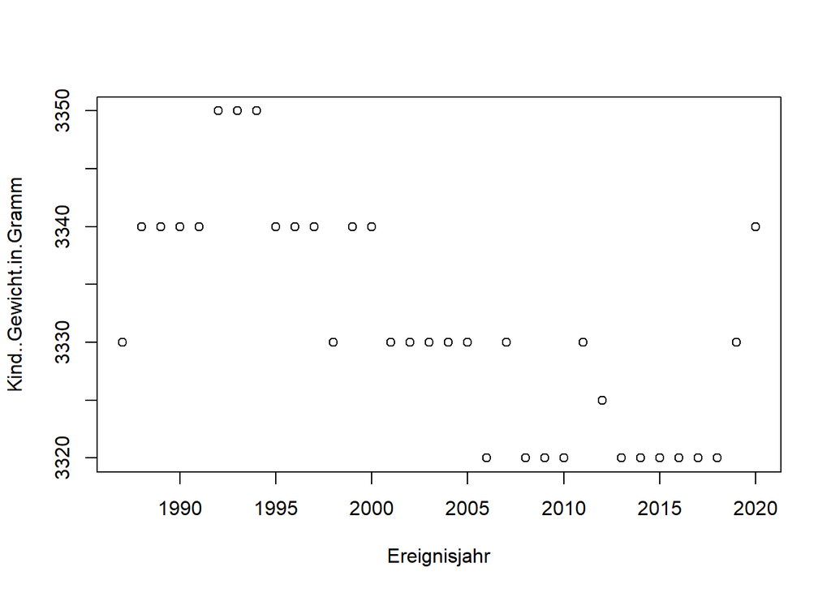

```r
plot(BW_median2)
```

## Length through the years

```r
BL_median <- aggregate(Kind..Grösse.in.Zentimeter ~ Ereignisjahr, data = bevn, median)
BL_median
```

```
##    Ereignisjahr Kind..Grösse.in.Zentimeter
## 1          1987                         50
## 2          1988                         50
## 3          1989                         50
## 4          1990                         50
## 5          1991                         50
## 6          1992                         50
## 7          1993                         50
## 8          1994                         50
## 9          1995                         50
## 10         1996                         50
## 11         1997                         50
## 12         1998                         50
## 13         1999                         50
## 14         2000                         50
```

[output cut: 20 more lines]

Birthlength is robustly consistent at 50cm, 1987-2020.

## Sex % through the years

```r
tab1<- table(bevn$Kind..Geschlecht, bevn$Ereignisjahr)
tab1
```

```
##
##      1987  1988  1989  1990  1991  1992  1993  1994  1995  1996  1997  1998
##   F 38142 39937 40362 42077 43101 43622 41748 41275 41009 41158 40143 39476
##   M 39998 42125 42678 44046 45679 45668 44101 43572 43048 43600 42215 41437
##
##      1999  2000  2001  2002  2003  2004  2005  2006  2007  2008  2009  2010
##   F 38988 39046 36845 36969 37303 38776 40307 41004 41944 42804 43618 45334
##   M 41182 41492 38982 39284 39363 40563 42782 43604 43949 45494 46479 47457
##
##      2011  2012  2013  2014  2015  2016  2017  2018  2019  2020
##   F 44866 45622 46181 47379 47808 49017 48223 48372 47241 46366
##   M 47458 48754 48829 50117 50880 51336 50827 50820 49801 49302
```

```r
round(prop.table(table(bevn$Kind..Geschlecht, bevn$Ereignisjahr), margin=2)*100,2)
```

```
##
##      1987  1988  1989  1990  1991  1992  1993  1994  1995  1996  1997  1998
##   F 48.81 48.67 48.61 48.86 48.55 48.85 48.63 48.65 48.79 48.56 48.74 48.79
##   M 51.19 51.33 51.39 51.14 51.45 51.15 51.37 51.35 51.21 51.44 51.26 51.21
##
##      1999  2000  2001  2002  2003  2004  2005  2006  2007  2008  2009  2010
##   F 48.63 48.48 48.59 48.48 48.66 48.87 48.51 48.46 48.83 48.48 48.41 48.86
##   M 51.37 51.52 51.41 51.52 51.34 51.13 51.49 51.54 51.17 51.52 51.59 51.14
##
##      2011  2012  2013  2014  2015  2016  2017  2018  2019  2020
##   F 48.60 48.34 48.61 48.60 48.44 48.84 48.69 48.77 48.68 48.47
##   M 51.40 51.66 51.39 51.40 51.56 51.16 51.31 51.23 51.32 51.53
```

```r
ratio <- (tab1[1,2]/tab1[1,1])
ratio
```

```
## [1] 1.047061
```

```r
38982/36845
```

```
## [1] 1.058
```

```r
##pb with creating sex ratio variable
```

## Stillbirth % through the years, their median GA and BW

```r
table(bevn$lebend.geboren.oder.nicht, bevn$Ereignisjahr, useNA="always")
```

```
##
##         1987  1988  1989  1990  1991  1992  1993  1994  1995  1996  1997  1998
##   1    77792 81736 82688 85718 88402 88938 85493 84551 83713 84440 82009 80599
##   2      348   326   352   405   378   352   356   296   344   318   349   314
##   <NA>     0     0     0     0     0     0     0     0     0     0     0     0
##
##         1999  2000  2001  2002  2003  2004  2005  2006  2007  2008  2009  2010
##   1    79889 80244 75542 75997 76351 79059 82764 84253 85580 87932 89725 92421
##   2      281   294   285   256   315   280   325   355   313   366   372   370
##   <NA>     0     0     0     0     0     0     0     0     0     0     0     0
##
##         2011  2012  2013  2014  2015  2016  2017  2018  2019  2020  <NA>
##   1    91958 93990 94594 97107 98310 99955 98676 98789 96684 95339     0
##   2      366   386   416   389   378   398   374   403   358   329     0
##   <NA>     0     0     0     0     0     0     0     0     0     0     0
```

```r
round(prop.table(table(bevn$lebend.geboren.oder.nicht, bevn$Ereignisjahr), margin=2)*100,3)
```

```
##
##       1987   1988   1989   1990   1991   1992   1993   1994   1995   1996
##   1 99.555 99.603 99.576 99.530 99.574 99.606 99.585 99.651 99.591 99.625
##   2  0.445  0.397  0.424  0.470  0.426  0.394  0.415  0.349  0.409  0.375
##
##       1997   1998   1999   2000   2001   2002   2003   2004   2005   2006
##   1 99.576 99.612 99.649 99.635 99.624 99.664 99.589 99.647 99.609 99.580
##   2  0.424  0.388  0.351  0.365  0.376  0.336  0.411  0.353  0.391  0.420
##
##       2007   2008   2009   2010   2011   2012   2013   2014   2015   2016
##   1 99.636 99.585 99.587 99.601 99.604 99.591 99.562 99.601 99.617 99.603
##   2  0.364  0.415  0.413  0.399  0.396  0.409  0.438  0.399  0.383  0.397
##
##       2017   2018   2019   2020
##   1 99.622 99.594 99.631 99.656
##   2  0.378  0.406  0.369  0.344
```

```r
#calculating median GA by year of birth, for stillborn
 GA_median <- aggregate(GA_weeks ~ Ereignisjahr, data = subset(bevn, lebend.geboren.oder.nicht==2 & Ereignisjahr >=2006), median)
 GA_median
```

```
##    Ereignisjahr GA_weeks
## 1          2006 28.35714
## 2          2007 30.85714
## 3          2008 28.28571
## 4          2009 29.64286
## 5          2010 27.85714
## 6          2011 29.14286
## 7          2012 27.71429
## 8          2013 28.57143
## 9          2014 29.42857
## 10         2015 29.28571
## 11         2016 30.00000
## 12         2017 28.28571
## 13         2018 28.42857
## 14         2019 31.14286
## 15         2020 30.57143
```

```r
 #calculating median BW for stillborn babies, by year
  BW_median_sb <- aggregate(Kind..Gewicht.in.Gramm ~ Ereignisjahr, data = subset(bevn, lebend.geboren.oder.nicht==2), median)
  BW_median_sb
```

```
##    Ereignisjahr Kind..Gewicht.in.Gramm
## 1          1987                 1940.0
## 2          1988                 2000.0
## 3          1989                 2000.0
## 4          1990                 2100.0
## 5          1991                 1920.0
## 6          1992                 2030.0
## 7          1993                 2135.0
## 8          1994                 2000.0
## 9          1995                 2050.0
## 10         1996                 1840.0
## 11         1997                 2030.0
## 12         1998                 1780.0
## 13         1999                 1840.0
## 14         2000                 1900.0
```

[output cut: 20 more lines]

Median GA varies betwen 27.71 and 31.14 weeks between 2006 and 2020.

## Age of the mother through the years

```r
AM_median <- aggregate(Mutter..Alter.in.erfüllten.Jahren ~ Ereignisjahr, data = bevn, median)
AM_median
```

```
##    Ereignisjahr Mutter..Alter.in.erfüllten.Jahren
## 1          1987                                28
## 2          1988                                28
## 3          1989                                28
## 4          1990                                28
## 5          1991                                28
## 6          1992                                28
## 7          1993                                29
## 8          1994                                29
## 9          1995                                29
## 10         1996                                29
## 11         1997                                30
## 12         1998                                30
## 13         1999                                30
## 14         2000                                30
```

[output cut: 20 more lines]

Maternal age varies increases between 28 and 32 yo between 1987 and 2020.

## Age difference between parents, through the years

```r
bevn$parent_age_diff <- (bevn$Vater..Alter.in.erfüllten.Jahren)-(bevn$Mutter..Alter.in.erfüllten.Jahren)
summary(bevn$parent_age_diff)
```

```
##    Min. 1st Qu.  Median    Mean 3rd Qu.    Max.    NA's
##  -31.00    0.00    2.00    3.05    5.00   65.00  178075
```

```r
agediff_y <- aggregate(parent_age_diff ~ Ereignisjahr, data = bevn, median)
agediff_y
```

```
##    Ereignisjahr parent_age_diff
## 1          1987               3
## 2          1988               3
## 3          1989               3
## 4          1990               3
## 5          1991               3
## 6          1992               2
## 7          1993               2
## 8          1994               2
## 9          1995               2
## 10         1996               2
## 11         1997               2
## 12         1998               2
## 13         1999               2
## 14         2000               2
```

[output cut: 20 more lines]

## Creating a variable combining month+year of birth

I created two variables for date : one combining month+year only, and another combining day+month+year. I set up day to 1st of each month in order to have variable m-d-y, easier to work with.

```r
bevn$birthdate3 <- with(bevn, sprintf("%d-%02d", Ereignisjahr, Ereignismonat))
tail(bevn$birthdate3)
```

```
## [1] "2020-12" "2020-12" "2020-12" "2020-12" "2020-12" "2020-12"
```

```r
head(bevn$birthdate3)
```

```
## [1] "1987-01" "1987-01" "1987-01" "1987-01" "1987-01" "1987-01"
```

```r
bevn$day <- 01
bevn$birthdate2 <- as.Date(paste(bevn$Ereignisjahr, bevn$Ereignismonat, bevn$day, sep='-'))
summary(bevn$birthdate2)
```

```
##         Min.      1st Qu.       Median         Mean      3rd Qu.         Max.
## "1987-01-01" "1995-10-01" "2005-02-01" "2004-07-19" "2013-06-01" "2020-12-01"
```

```r
tail(bevn$birthdate2)
```

```
## [1] "2020-12-01" "2020-12-01" "2020-12-01" "2020-12-01" "2020-12-01"
## [6] "2020-12-01"
```

```r
head(bevn$birthdate2)
```

```
## [1] "1987-01-01" "1987-01-01" "1987-01-01" "1987-01-01" "1987-01-01"
## [6] "1987-01-01"
```

# Simple plots

## BW or BL depending on GA and

2 different sets with either all birthweights/GA or birtsweights “normal” ]100;8000[ and GA >20 weeks and with either all birthlengths or “normal” birthlengths ]10,60[ and GA >20 weeks

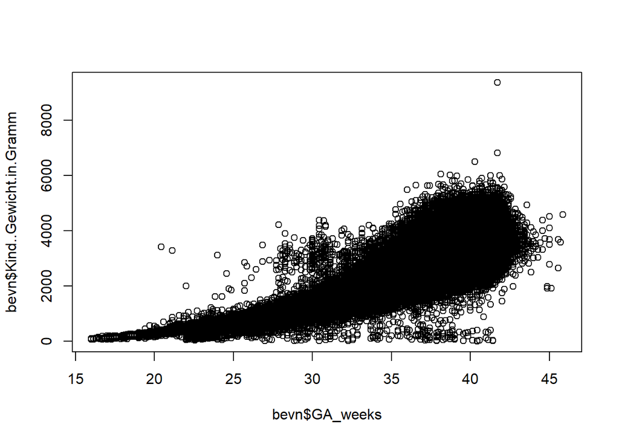

```r
plot(bevn$GA_weeks,bevn$Kind..Gewicht.in.Gramm) #BW and GA, all birthweights
```

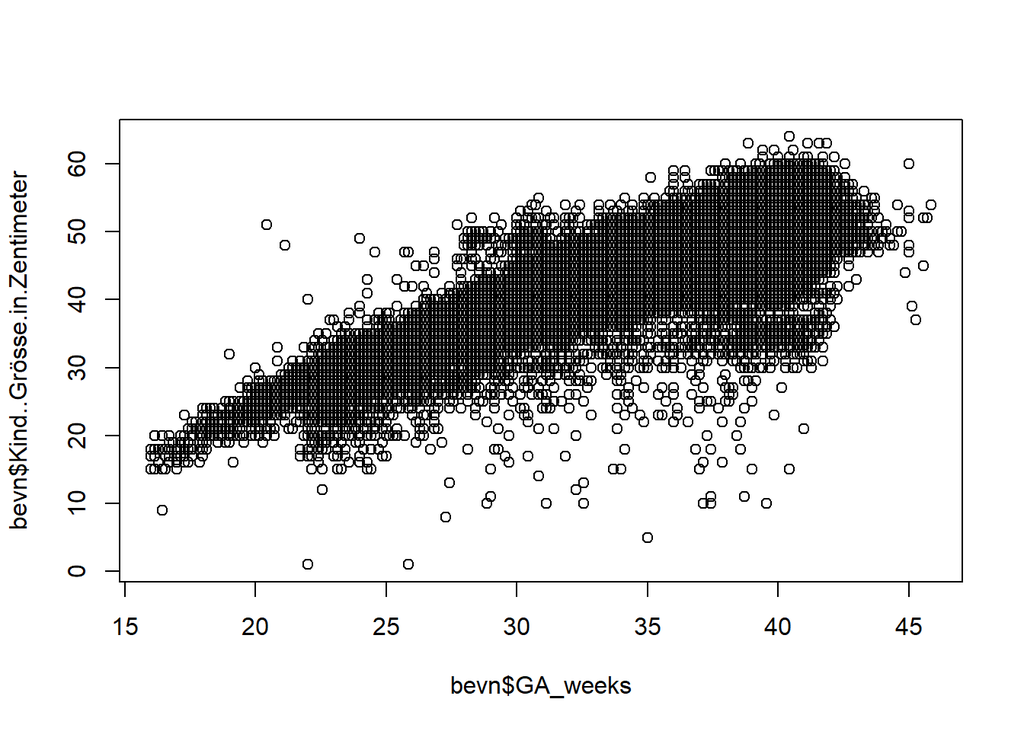

```r
plot(bevn$GA_weeks, bevn$Kind..Grösse.in.Zentimeter) #BL and GA, all birthlengths
```

```r
BW_normal <- subset(bevn, Kind..Gewicht.in.Gramm>100 & Kind..Gewicht.in.Gramm <8000 & GA_weeks>20)
summary(BW_normal$Kind..Gewicht.in.Gramm)
```

```
##    Min. 1st Qu.  Median    Mean 3rd Qu.    Max.
##     101    3000    3320    3286    3640    6820
```

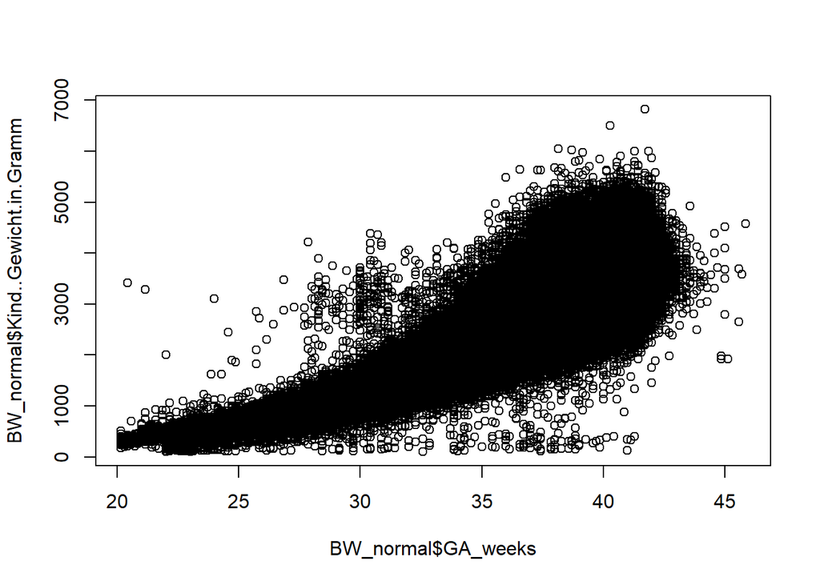

```r
plot(BW_normal$GA_weeks, BW_normal$Kind..Gewicht.in.Gramm) #BW and GA, BW ]100;8000[
```

```r
BL_normal <- subset(bevn, Kind..Grösse.in.Zentimeter>10 & Kind..Grösse.in.Zentimeter <60  & GA_weeks>20)
summary(BL_normal$Kind..Grösse.in.Zentimeter)
```

```
##    Min. 1st Qu.  Median    Mean 3rd Qu.    Max.
##   11.00   48.00   50.00   49.32   51.00   59.00
```

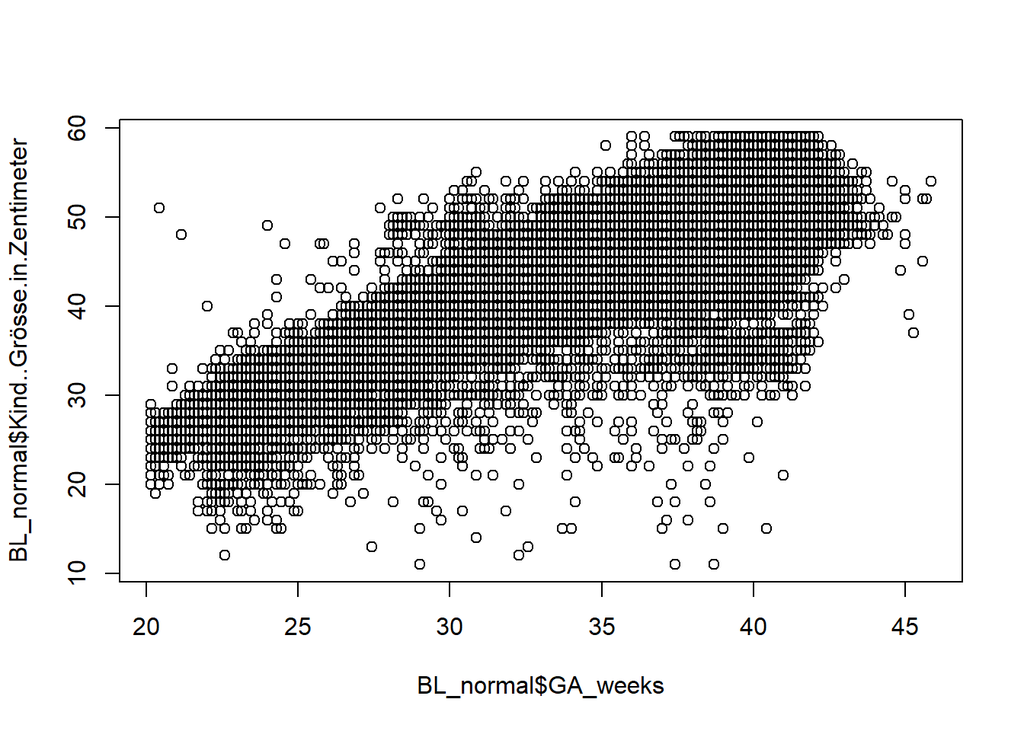

```r
plot(BL_normal$GA_weeks, BL_normal$Kind..Grösse.in.Zentimeter) #BL and GA, BL ]10;60[
```

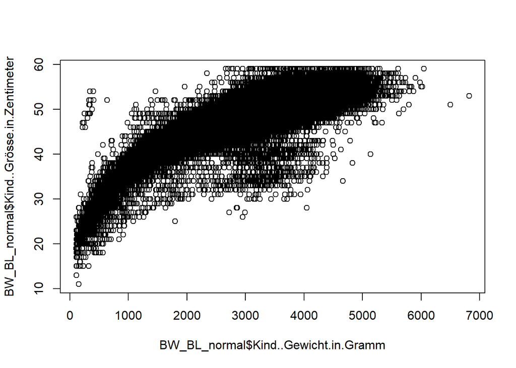

```r
BW_BL_normal <- subset(bevn, Kind..Grösse.in.Zentimeter>10 & Kind..Grösse.in.Zentimeter <60 & Kind..Gewicht.in.Gramm>100 & Kind..Gewicht.in.Gramm <8000  & GA_weeks>20)
plot(BW_BL_normal$Kind..Gewicht.in.Gramm,BW_BL_normal$Kind..Grösse.in.Zentimeter) #BW and BL
```

## Birthweight change through the years: Simple model

```r
##boxplot(bevn$Ereignisjahr, bevn$Kind..Gewicht.in.Gramm) ##doesnt work
BW_years <- lm(Kind..Gewicht.in.Gramm~Ereignisjahr, data=bevn)
summary(BW_years)
```

```
##
## Call:
## lm(formula = Kind..Gewicht.in.Gramm ~ Ereignisjahr, data = bevn)
##
## Residuals:
##     Min      1Q  Median      3Q     Max
## -3277.4  -288.8    32.5   345.3  6070.6
##
## Coefficients:
##               Estimate Std. Error t value Pr(>|t|)
## (Intercept)  5860.3264    66.3249   88.36   <2e-16 ***
## Ereignisjahr   -1.2785     0.0331  -38.62   <2e-16 ***
## ---
## Signif. codes:  0 '***' 0.001 '**' 0.01 '*' 0.05 '.' 0.1 ' ' 1
##
## Residual standard error: 554.6 on 2821506 degrees of freedom
##   (151477 observations deleted due to missingness)
## Multiple R-squared:  0.0005284,  Adjusted R-squared:  0.0005281
## F-statistic:  1492 on 1 and 2821506 DF,  p-value: < 2.2e-16
```

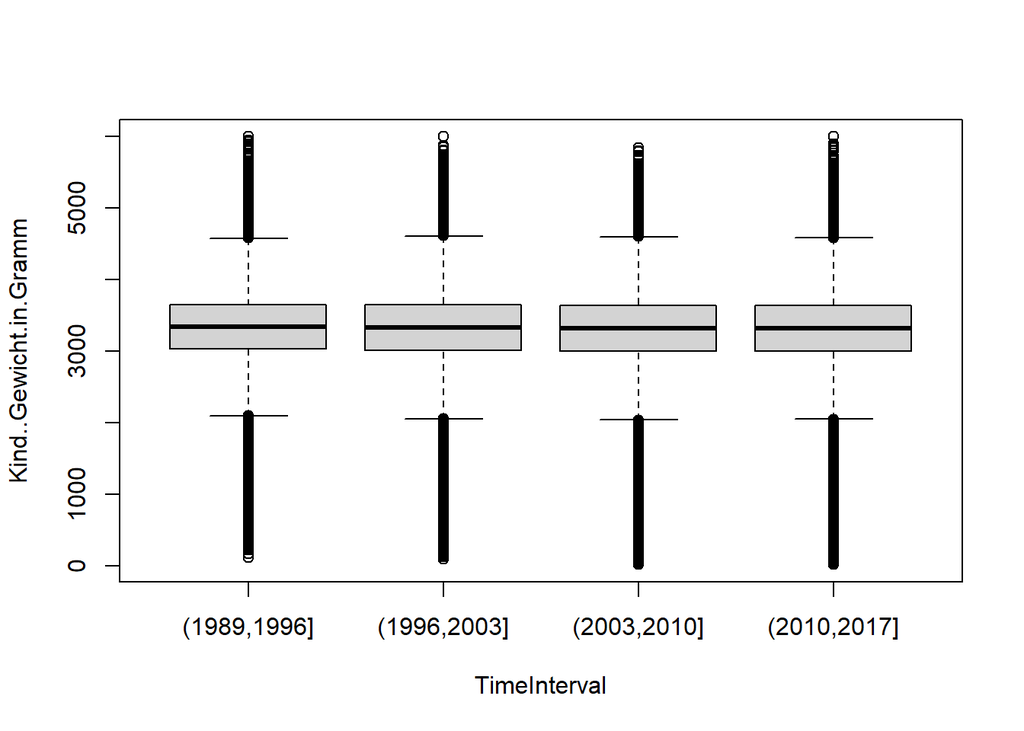

```r
library(ggplot2)
##ggplot(bevn, aes(x=Ereignisjahr, y=Kind..Gewicht.in.Gramm)) ##doesnt work

bevn$TimeInterval <- cut(bevn$Ereignisjahr, breaks=c(1989, 1996, 2003, 2010, 2017))
boxplot(Kind..Gewicht.in.Gramm~TimeInterval, data=bevn)
```

```r
meanBW <- mean(bevn$Kind..Gewicht.in.Gramm)
##ggplot(bevn, aes(x=Ereignisjahr, y=meanBW)) ##doesnt work

##BW_time <- lm(Kind..Gewicht.in.Gramm~birthdate3, data=bevn) ##doesnt work

BW_time <- lm(Kind..Gewicht.in.Gramm~birthdate2, data=bevn)
summary(BW_time)
```

```
##
## Call:
## lm(formula = Kind..Gewicht.in.Gramm ~ birthdate2, data = bevn)
##
## Residuals:
##     Min      1Q  Median      3Q     Max
## -3277.0  -288.7    32.5   345.2  6071.1
##
## Coefficients:
##               Estimate Std. Error t value Pr(>|t|)
## (Intercept)  3.343e+03  1.177e+00 2840.33   <2e-16 ***
## birthdate2  -3.512e-03  9.057e-05  -38.77   <2e-16 ***
## ---
## Signif. codes:  0 '***' 0.001 '**' 0.01 '*' 0.05 '.' 0.1 ' ' 1
##
## Residual standard error: 554.6 on 2821506 degrees of freedom
##   (151477 observations deleted due to missingness)
## Multiple R-squared:  0.0005326,  Adjusted R-squared:  0.0005322
## F-statistic:  1504 on 1 and 2821506 DF,  p-value: < 2.2e-16
```